# Project: Investigate a Dataset - Medical Appointment No Shows

- Introduction
- Data Wrangling
- Exploratory Data Analysis
- Conclusions

## Introduction

### Dataset Description

> This [dataset](https://www.kaggle.com/datasets/joniarroba/noshowappointments?datasetId=792&sortBy=voteCount) is taken from Kaggle and it collects information from 100k medical appointments in Brazil and is focused on the question of whether or not patients show up for their appointment. A number of characteristics about the patient are included in each row.
> - **PatientId:** Identification of a patient
> - **AppointmentID:** Identification of each appointment
> - **Gender:** Male or Female . gender of the patient
> - **ScheduledDay:** The day someone called or registered the appointment, this is before appointment of course.
> - **AppointmentDay:** The day of the actuall appointment, when they have to visit the doctor.
> - **Age:** The age of the patient.
> - **Neighbourhood:** Appointment location.
> - **Scholarship:** Indicates whether or not the patient is enrolled in [Brasilian welfare program](https://en.wikipedia.org/wiki/Bolsa_Fam%C3%ADlia)
> - **Hipertension:** Indicates whether or not the patient have hipertension
> - **Diabetes:** Indicates whether or not the patient have diabetes
> - **Alcoholism** Indicates whether or not the patient have alcoholism
> - **Handcap** Indicates whether or not the patient has a handicap
> - **SMS_received** Indicates whether or not at least 1 message was sent to the patient
> - **No-show** Indicates whether or not the patient showed up to their appointment

### Question(s) for Analysis

> Which gender has the highest average age?

> What are the characteristics of patients who do not appear on their scheduled appointment date?

> What are the neighborhoods with the lowest attendance rate?

```python
#Importing necessary libraries
import pandas as pd
import numpy as np
import matplotlib.pyplot as plt
import seaborn as sns

%matplotlib inline
```

## Data Wrangling

> In this section of the report, we will load in the data, check for cleanliness, and then trim and clean the dataset for analysis.

### General Properties

> Here we are going load the data and conduct operations to analyze data types and look for instances of missing or possibly errant data.

```python
#Loading the data and printing out the first two lines
file = 'Database_No_show_appointments/noshowappointments-kagglev2-may-2016.csv'
df = pd.read_csv(file)
df.head(2)
```

|  | PatientId | AppointmentID | Gender | ScheduledDay | AppointmentDay | Age | Neighbourhood | Scholarship | Hipertension | Diabetes | Alcoholism | Handcap | SMS_received | No-show |
| --- | --- | --- | --- | --- | --- | --- | --- | --- | --- | --- | --- | --- | --- | --- |
| 0 | 2.987250e+13 | 5642903 | F | 2016-04-29T18:38:08Z | 2016-04-29T00:00:00Z | 62 | JARDIM DA PENHA | 0 | 1 | 0 | 0 | 0 | 0 | No |
| 1 | 5.589978e+14 | 5642503 | M | 2016-04-29T16:08:27Z | 2016-04-29T00:00:00Z | 56 | JARDIM DA PENHA | 0 | 0 | 0 | 0 | 0 | 0 | No |

We can see that there are typos in some of the attribute names we will fix them later.

Now lets take a look at our data shape.

```python
#checking data shape
df.shape
```

```
(110527, 14)
```

```python
#Cheking the number of unique values of each attribute
df.nunique()
```

```
PatientId          62299
AppointmentID     110527
Gender                 2
ScheduledDay      103549
AppointmentDay        27
Age                  104
Neighbourhood         81
Scholarship            2
Hipertension           2
Diabetes               2
Alcoholism             2
Handcap                5
SMS_received           2
No-show                2
dtype: int64
```

It seems like each row corresponds to an appointment since the number of unique values for the AppointmentID column is equal to the number of rows in the dataset.  
It would be more convenient to set the *"AppointmentId"* column as the index column so that each data row can be addressed with a unique identifier.

Now lets look at further information regarding the data types and number of missing values for each feature

```python
#Further investigation
df.info()
```

```
<class 'pandas.core.frame.DataFrame'>
RangeIndex: 110527 entries, 0 to 110526
Data columns (total 14 columns):
PatientId         110527 non-null float64
AppointmentID     110527 non-null int64
Gender            110527 non-null object
ScheduledDay      110527 non-null object
AppointmentDay    110527 non-null object
Age               110527 non-null int64
Neighbourhood     110527 non-null object
Scholarship       110527 non-null int64
Hipertension      110527 non-null int64
Diabetes          110527 non-null int64
Alcoholism        110527 non-null int64
Handcap           110527 non-null int64
SMS_received      110527 non-null int64
No-show           110527 non-null object
dtypes: float64(1), int64(8), object(5)
memory usage: 11.8+ MB
```

The above output shows that we have no missing data since the number of non-null values for each attribute equals the number of instances in the dataset.

Several type conversions needs to be done:

- Convert *"**ScheduledDay**"* and *"**AppointmentDay**"* to `datetime` since they represents date
- Convert *"Gender", "Neighborhood", "Scholarship", "Hypertension", "Diabetes", "Alcoholism", "Handicap", "SMS_received", "No_show"* to `category`

It's time to check for duplicates

```python
#checking duplicates
df.duplicated().sum()
```

```
0
```

```python
#rechecking duplicates
df.duplicated(df.columns.delete(3)).sum()
```

```
0
```

Now, let's check extreme values for continuous features

```python
#Checking for extreme values
df.Age.describe()
```

```
count    110527.000000
mean         37.088874
std          23.110205
min          -1.000000
25%          18.000000
50%          37.000000
75%          55.000000
max         115.000000
Name: Age, dtype: float64
```

Age can't be negative !  
Let's see how many rows with negative age in the dataset in order to determine how to approach this problem.

```python
df.query('Age < 0')
```

|  | PatientId | AppointmentID | Gender | ScheduledDay | AppointmentDay | Age | Neighbourhood | Scholarship | Hipertension | Diabetes | Alcoholism | Handcap | SMS_received | No-show |
| --- | --- | --- | --- | --- | --- | --- | --- | --- | --- | --- | --- | --- | --- | --- |
| 99832 | 4.659432e+14 | 5775010 | F | 2016-06-06T08:58:13Z | 2016-06-06T00:00:00Z | -1 | ROMÃO | 0 | 0 | 0 | 0 | 0 | 0 | No |

Fortunately, we only have one entry with irrelevant age, thus removing it will be a good approach.

### Data Cleaning

> Now that we have discussed the structure of the data and any problems that need to be cleaned let's go on performing the cleaning steps

Fixing multiple column names typos

```python
#Fixing typos
df.rename(columns={'Neighbourhood':'Neighborhood', 'Hipertension':'Hypertension', 'Handcap':'Handicap', 'No-show':'No_show', }, inplace=True)
```

Setting *"**AppointmentID**"* column as index

```python
#Setting index
df.set_index('AppointmentID', inplace=True)
df.head(1)
```

| AppointmentID | PatientId | Gender | ScheduledDay | AppointmentDay | Age | Neighborhood | Scholarship | Hypertension | Diabetes | Alcoholism | Handicap | SMS_received | No_show |
| --- | --- | --- | --- | --- | --- | --- | --- | --- | --- | --- | --- | --- | --- |
| 5642903 | 2.987250e+13 | F | 2016-04-29T18:38:08Z | 2016-04-29T00:00:00Z | 62 | JARDIM DA PENHA | 0 | 1 | 0 | 0 | 0 | 0 | No |

Data type conversion

```python
#Converting date attributes
df['ScheduledDay']= pd.to_datetime(df['ScheduledDay'])
df['AppointmentDay']= pd.to_datetime(df['AppointmentDay'])
```

```python
#Conveting categorical variables
cat_features = ['Gender','Neighborhood','Scholarship','Hypertension','Diabetes','Alcoholism','Handicap','SMS_received','No_show']
df[cat_features]= df[cat_features].astype('category')
```

Removing duplicates

```python
#Dropping duplicates
df.drop_duplicates(df.columns.delete(3), inplace=True)

#Rechecking duplicates
df.duplicated().sum()
```

```
0
```

Removing rows with negative ages

```python
#Removing irrelevant rows
df.drop(df.query('Age < 0').index, inplace=True)
```

Now let's see a final look to our data after cleaning

```python
df.info()
```

```
<class 'pandas.core.frame.DataFrame'>
Int64Index: 109908 entries, 5642903 to 5629448
Data columns (total 13 columns):
PatientId         109908 non-null float64
Gender            109908 non-null category
ScheduledDay      109908 non-null datetime64[ns]
AppointmentDay    109908 non-null datetime64[ns]
Age               109908 non-null int64
Neighborhood      109908 non-null category
Scholarship       109908 non-null category
Hypertension      109908 non-null category
Diabetes          109908 non-null category
Alcoholism        109908 non-null category
Handicap          109908 non-null category
SMS_received      109908 non-null category
No_show           109908 non-null category
dtypes: category(9), datetime64[ns](2), float64(1), int64(1)
memory usage: 5.1 MB
```

## Exploratory Data Analysis

> In this section we are going to address the research questions that we have posed in the Introduction section, and compute some relevant statistics about our data

### 1: Which gender has the highest average age?

We need to remove duplicated patients so that we can find more accurate results

```python
patients_df = df.drop_duplicates(subset="PatientId")
```

```python
genre_prop = patients_df.Gender.value_counts() / len(patients_df)
genre_prop
```

```
F    0.642798
M    0.357202
Name: Gender, dtype: float64
```

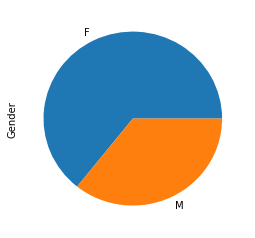

```python
genre_prop.plot.pie(figsize=(4,4));
```

We can see that our data contains more information about females patients

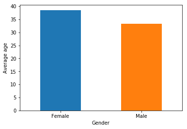

```python
patients_df.groupby('Gender')['Age'].mean().plot(kind='bar');
plt.xticks([0,1],['Female', 'Male'],rotation=0);
plt.ylabel('Average age');
```

We can clearly see that females have higher average age than males

### 2: What are the characteristics of patients who do not appear on their scheduled appointment date?

In this section we are going to look into some characteristics associated with missing an appointment. To do so, we need to go through all the attributes we have to determine if they relate in any way to skipping an appointment.

#### 2.1 Which medical condition is associated the most with missing an appointment?

```python
#Selecting columns relating to medical condition
med_cols = ['Hypertension', 'Diabetes', 'Alcoholism', 'Handicap']

#looking in some statistics
df.query('No_show == "Yes"')[med_cols].describe()
```

|  | Hypertension | Diabetes | Alcoholism | Handicap |
| --- | --- | --- | --- | --- |
| count | 22105 | 22105 | 22105 | 22105 |
| unique | 2 | 2 | 2 | 5 |
| top | 0 | 0 | 0 | 0 |
| freq | 18375 | 20683 | 21437 | 21706 |

```python
df.describe()
```

|  | PatientId | Age |
| --- | --- | --- |
| count | 1.099080e+05 | 109908.000000 |
| mean | 1.474548e+14 | 37.086818 |
| std | 2.560484e+14 | 23.121310 |
| min | 3.921784e+04 | 0.000000 |
| 25% | 4.172982e+12 | 18.000000 |
| 50% | 3.172598e+13 | 37.000000 |
| 75% | 9.439381e+13 | 55.000000 |
| max | 9.999816e+14 | 115.000000 |

```python
df.Handicap.value_counts()
```

```
0    107689
1      2023
2       182
3        11
4         3
Name: Handicap, dtype: int64
```

The signification of each value for this attribute was not provided, Perhaps it corresponds to the number of handicaps or the nature of one's handicap. Replacing any value above 1 by 1 is a good approach to the problem.

```python
#replacing values above 1 by 1
df.Handicap = df.Handicap.replace({2:1, 3:1, 4:1}).astype('category')
```

```python
df.Handicap.value_counts()
```

```
0    107689
1      2219
Name: Handicap, dtype: int64
```

To make the code reusable and avoid repetition, let's create a function that calculates for us some useful statistical calculations

```python
def compute_stats(df, col, query):

    """
    Generates statistics about a given DataFrame column under a condition.

    This function perform and return some statistics over a DataFrame column including
    absolute value counts and value counts under a given condition

    Arguments:
        data : DataFrame
        col : string
            Column name from df
        query : string
            The query string to apply on df

    Returns:
        result_df : DataFrame

    """
    #Creating dataframe that contains absolute value counts
    result_df = df[col].value_counts().to_frame(name='Total')

    #Applying query and storing results
    filtred_df = df.query(query)

    #Adding partial value counts to the dataframe
    result_df['Filtred_total'] = filtred_df[col].value_counts()

    #Adding the proportion of filtred results
    result_df['Proportion'] = result_df['Filtred_total']/result_df['Total']


    return(result_df)
```

```python
#Creating dataframae to contain statistics about each medical condition
med_df = pd.DataFrame()

#filling in dataframe with stats
for col in med_cols:
    med_df[col] = compute_stats(df, col, 'No_show == "Yes"').Proportion

med_df
```

|  | Hypertension | Diabetes | Alcoholism | Handicap |
| --- | --- | --- | --- | --- |
| 0 | 0.208262 | 0.202745 | 0.201165 | 0.201562 |
| 1 | 0.172064 | 0.180160 | 0.199761 | 0.179811 |

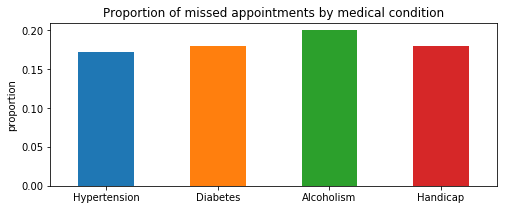

```python
med_df.iloc[1].plot(kind='bar', figsize=(8,3))
plt.xticks(rotation=0);
plt.ylabel('proportion')
plt.title('Proportion of missed appointments by medical condition');
```

The above plot shows that patients with alcoholism have the highest no-showing rate compared to patients with other health problems

#### 2.2 Do patients with more health problems have a higher attendance rate?

First we need to calculate the number of health problems for each patient

```python
#Computing the sum of health-related columns
df['medical_condition'] = df[med_cols].sum(axis=1)
```

```python
med_stats = compute_stats(df, 'medical_condition', 'No_show == "No"')
med_stats
```

|  | Total | Filtred_total | Proportion |
| --- | --- | --- | --- |
| 0.0 | 83647 | 66206 | 0.791493 |
| 1.0 | 18030 | 14819 | 0.821908 |
| 2.0 | 7602 | 6247 | 0.821757 |
| 3.0 | 616 | 522 | 0.847403 |
| 4.0 | 13 | 9 | 0.692308 |

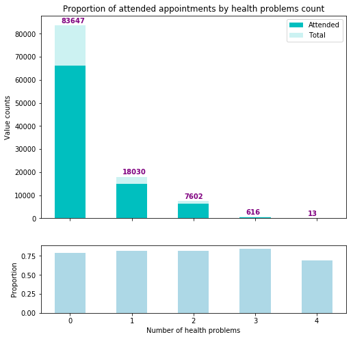

```python
fig, ax = plt.subplots(2,1, gridspec_kw={'height_ratios':[3,1]} ,sharex=True)
fig.set_size_inches(8,8)

#y coordinates of the bars
y = np.arange(len(med_stats))

#Plotting value counts
ax[0].bar(y, med_stats['Filtred_total'],.5, color='c', label='Attended')
ax[0].bar(y, med_stats['Total'], .5, color='c', alpha=.2, label='Total')
ax[0].set_title('Proportion of attended appointments by health problems count')
ax[0].set_ylabel('Value counts')
ax[0].legend();

#Display each bar value
for i, v in enumerate(med_stats['Total']):
    ax[0].text(i-.15 , v + 1000, str(v), color = 'purple', fontweight = 'bold')

#plotting proportions
ax[1].bar(y, med_stats['Proportion'],.5, color='lightblue', tick_label=med_stats.index)
ax[1].set_xticklabels(np.arange(5))
ax[1].set_xlabel('Number of health problems')
ax[1].set_ylabel('Proportion');
```

Here we don't see a clear pattern between patients attendance and medical condition.  
first the attendance seems to be slightly increasing with the increase of health problems and then it does the opposite where we can notice that patients with the higher number of medical propblems have the lowest attendance rate.

#### 2.3 Which day of the week has the highest attendance rate?

Let's first create a variable to contain the week day of each appointment

```python
df['weekday'] = df['ScheduledDay'].apply(lambda row: row.weekday())
```

```python
weekdayk_stats = compute_stats(df, 'weekday', 'No_show == "No"')
weekdayk_stats
```

|  | Total | Filtred_total | Proportion |
| --- | --- | --- | --- |
| 1 | 26049 | 20786 | 0.797958 |
| 2 | 24136 | 19295 | 0.799428 |
| 0 | 22951 | 18439 | 0.803407 |
| 4 | 18801 | 14967 | 0.796075 |
| 3 | 17948 | 14294 | 0.796412 |
| 5 | 23 | 22 | 0.956522 |

[figure not shown]

```python
fig, ax = plt.subplots(2,1, gridspec_kw={'height_ratios':[3,1]} ,sharex=True)
fig.set_size_inches(8,8)

#y coordinates of the bars
y = np.arange(len(weekdayk_stats))

#Plotting value counts
ax[0].bar(y, weekdayk_stats['Filtred_total'],.5, color='c', label='Attended')
ax[0].bar(y, weekdayk_stats['Total'], .5, color='c', alpha=.2, label='Total')
ax[0].set_title('Proportion of attended appointments per neighborhood')
ax[0].set_ylabel('Value counts')
ax[0].set_xticklabels(['Monday' 'Tuesday' 'Wednesday' 'Thursday' 'Friday' 'Saturday'])
ax[0].legend();

#Display each bar value
for i, v in enumerate(weekdayk_stats['Total']):
    ax[0].text(i- .2, v+200 , str(v), color = 'purple', fontweight = 'bold')

#plotting proportions
ax[1].bar(y, weekdayk_stats['Proportion'],.5, color='lightblue', tick_label=weekdayk_stats.index)
ax[1].set_xticks(np.arange(7))
ax[1].set_xticklabels(['Monday', 'Tuesday', 'Wednesday', 'Thursday', 'Friday', 'Saturday'])
ax[1].set_xlabel('day of week')
ax[1].set_ylabel('Proportion');
```

Again, we can't find a clear pattern between days of the week and the showing rate, all proportions seems to have a very close value,  
but we can notice that we dont have appointments on sundays and we have few on saturdays

#### 2.4 Are patients who received sms messages more likely to attend their appointments?

```python
SMS_df = compute_stats(df, 'SMS_received', 'No_show == "No"')
SMS_df
```

|  | Total | Filtred_total | Proportion |
| --- | --- | --- | --- |
| 0 | 74426 | 62105 | 0.834453 |
| 1 | 35482 | 25698 | 0.724255 |

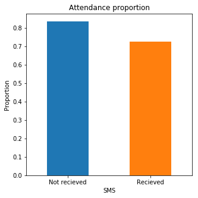

```python
SMS_df.Proportion.plot.bar(figsize=(5,5));
plt.xticks(SMS_df.index,['Not recieved', 'Recieved'], rotation=0);
plt.title('Attendance proportion')
plt.ylabel('Proportion');
plt.xlabel('SMS');
```

#### 2.5 Are patients who have scholarship more likely to attend their appointments?

```python
Scholarship_df = compute_stats(df, 'Scholarship', 'No_show == "No"')
Scholarship_df
```

|  | Total | Filtred_total | Proportion |
| --- | --- | --- | --- |
| 0 | 99106 | 79558 | 0.802757 |
| 1 | 10802 | 8245 | 0.763285 |

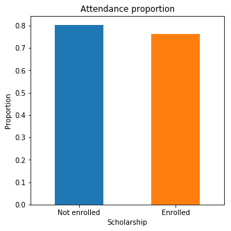

```python
Scholarship_df.Proportion.plot.bar(figsize=(5,5));
plt.xticks(SMS_df.index,['Not enrolled', 'Enrolled'], rotation=0);
plt.title('Attendance proportion')
plt.ylabel('Proportion');
plt.xlabel('Scholarship');
```

The above plot shows that patients who are not enrolled in a scholarship have higher attendance rate than those who do

#### 2.6 what time of the day has the highest attendance rate

```python
df['ScheduledHour'] = df['ScheduledDay'].apply(lambda row: row.strftime("%H"))
```

```python
Hour_df = compute_stats(df, 'ScheduledHour', 'No_show == "No"')
Hour_df.sort_index(inplace=True)
Hour_df
```

|  | Total | Filtred_total | Proportion |
| --- | --- | --- | --- |
| 06 | 1576 | 1274 | 0.808376 |
| 07 | 19161 | 16261 | 0.848651 |
| 08 | 15243 | 12476 | 0.818474 |
| 09 | 12753 | 10247 | 0.803497 |
| 10 | 10965 | 8562 | 0.780848 |
| 11 | 8396 | 6486 | 0.772511 |
| 12 | 5392 | 4302 | 0.797849 |
| 13 | 8982 | 7108 | 0.791360 |
| 14 | 9072 | 7025 | 0.774361 |
| 15 | 8037 | 6178 | 0.768695 |
| 16 | 5508 | 4204 | 0.763253 |
| 17 | 2899 | 2183 | 0.753018 |
| 18 | 1338 | 1053 | 0.786996 |
| 19 | 485 | 373 | 0.769072 |
| 20 | 98 | 69 | 0.704082 |
| 21 | 3 | 2 | 0.666667 |

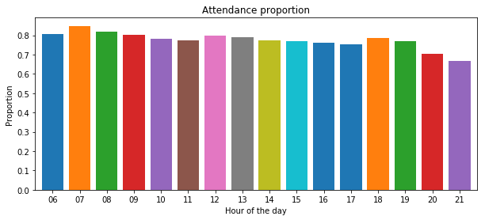

```python
Hour_df.Proportion.plot.bar(figsize=(10,4), width=.8);
plt.xticks(rotation=0);
plt.title('Attendance proportion')
plt.ylabel('Proportion');
plt.xlabel('Hour of the day');
```

To clearly spot changes over day hours let's take a look at a line plot

[figure not shown]

```python
Hour_df.Proportion.plot(figsize=(10,4))
plt.xticks(rotation=0);
plt.title('Attendance proportion')
plt.ylabel('Proportion');
plt.xticks(np.arange(len(Hour_df)),np.arange(len(Hour_df))+7,rotation=0);
plt.xlabel('Hour of the day');
```

The plot above indicates a low attendance rate at late hours of the day and a higher attendance in the mornings and early evenings.

### 3: What are the neighborhoods with the lowest attendance rate ?

Let's re-use the function `compute_stats` that we created earlier.

```python
hoods_stats = compute_stats(df, 'Neighborhood', 'No_show == "No"').sort_values(by='Proportion', ascending=False)
hoods_stats.head(2)
```

|  | Total | Filtred_total | Proportion |
| --- | --- | --- | --- |
| PARQUE INDUSTRIAL | 1 | 1 | 1.000000 |
| ILHA DO BOI | 35 | 32 | 0.914286 |

For clarity sake let's give the dataframe more accurate column names

```python
hoods_stats.rename(columns={'Filtred_total':'Attended','Proportion':'Attendance_prop'}, inplace=True)
hoods_stats.head(1)
```

|  | Total | Attended | Attendance_prop |
| --- | --- | --- | --- |
| PARQUE INDUSTRIAL | 1 | 1 | 1.0 |

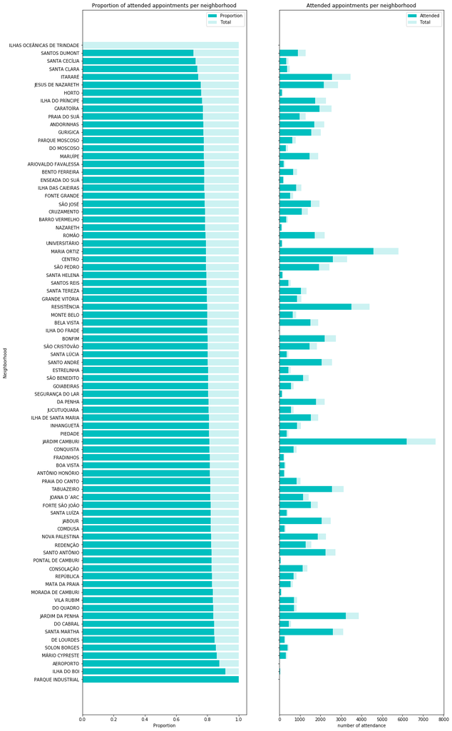

```python
fig, ax = plt.subplots(1,2, sharey=True)
fig.set_size_inches(15,30)

#y coordinates of the bars
y = np.arange(len(hoods_stats))

#plotting proportions
ax[0].barh(y, hoods_stats['Attendance_prop'], color='c', tick_label=hoods_stats.index, label='Proportion')
ax[0].barh(y, 1, .8, color='c', alpha=.2, label='Total')
ax[0].set_title('Proportion of attended appointments per neighborhood')
ax[0].set_xlabel('Proportion')
ax[0].set_ylabel('Neighborhood')
ax[0].legend();

#plotting value counts
ax[1].barh(y, hoods_stats['Attended'],.8, color='c', label='Attended')
ax[1].barh(y, hoods_stats['Total'], .8, color='c', alpha=.2, label='Total')
ax[1].set_title('Attended appointments per neighborhood')
ax[1].set_xlabel('number of attendance')
ax[1].legend();
```

By plotting the ordered attendance proportion and the number of attendance for each neighbourhood, we can clearly distinguish the neighbourhoods with the lowest attendance while taking into account the actual attendance figures

## Conclusions

> **LImitation**:  
> From the date columns we can see that this observations were spread out only across a month, working on a snapshot of data prevent us from providing a complete picture of the data. if data were spread out over a longer periode we could have discovered some patterns over months, semesters or maybe years.

```python
from subprocess import call
call(['python', '-m', 'nbconvert', 'Investigate_a_Dataset.ipynb'])
```

```
0
```